# Epi_ML_7_Assignment

Arielle Coq / AC4140

3/3/2020

#### Question 1

First cleaned the data the same way that was done in class and partition the data into testing and training data sets to 30/70 partition. Removed the missing values and also created the outcome varaible so that it is Heart disease present or not present. The seed is set at 100 for this analysis.

```r
heart.data <- read.csv("processed.cleveland.data", header=FALSE)

var.names<-c("age", "sex", "pain_type", "resting_sysbp", "chol", "fast_blsugar_gt120", "rest_ecg", "max_hr", "exerc_angina", "ST_depression", "ST_slope", "vessels_colorflu", "defect", "heart_disease_present")

colnames(heart.data)<-var.names
str(heart.data)
```

```
## 'data.frame':    303 obs. of  14 variables:
##  $ age                  : num  63 67 67 37 41 56 62 57 63 53 ...
##  $ sex                  : num  1 1 1 1 0 1 0 0 1 1 ...
##  $ pain_type            : num  1 4 4 3 2 2 4 4 4 4 ...
##  $ resting_sysbp        : num  145 160 120 130 130 120 140 120 130 140 ...
##  $ chol                 : num  233 286 229 250 204 236 268 354 254 203 ...
##  $ fast_blsugar_gt120   : num  1 0 0 0 0 0 0 0 0 1 ...
##  $ rest_ecg             : num  2 2 2 0 2 0 2 0 2 2 ...
##  $ max_hr               : num  150 108 129 187 172 178 160 163 147 155 ...
##  $ exerc_angina         : num  0 1 1 0 0 0 0 1 0 1 ...
##  $ ST_depression        : num  2.3 1.5 2.6 3.5 1.4 0.8 3.6 0.6 1.4 3.1 ...
##  $ ST_slope             : num  3 2 2 3 1 1 3 1 2 3 ...
##  $ vessels_colorflu     : Factor w/ 5 levels "?","0.0","1.0",..: 2 5 4 2 2 2 4 2 3 2 ...
##  $ defect               : Factor w/ 4 levels "?","3.0","6.0",..: 3 2 4 2 2 2 2 2 4 4 ...
##  $ heart_disease_present: int  0 2 1 0 0 0 3 0 2 1 ...
```

```r
heart.data[heart.data=="?"]<-NA

heart.data$defect<-as.numeric(factor(heart.data$defect))
heart.data$vessels_colorflu<-as.numeric(factor(heart.data$vessels_colorflu))

heart.data$outcome<-ifelse(heart.data$heart_disease_present==0, 0,1)
heart.data$heart_disease_present<-NULL
heart.data$outcome<-factor(heart.data$outcome)
levels(heart.data$outcome)<-c("Not Present", "Present")
str(heart.data)
```

```
## 'data.frame':    303 obs. of  14 variables:
##  $ age               : num  63 67 67 37 41 56 62 57 63 53 ...
##  $ sex               : num  1 1 1 1 0 1 0 0 1 1 ...
##  $ pain_type         : num  1 4 4 3 2 2 4 4 4 4 ...
##  $ resting_sysbp     : num  145 160 120 130 130 120 140 120 130 140 ...
##  $ chol              : num  233 286 229 250 204 236 268 354 254 203 ...
##  $ fast_blsugar_gt120: num  1 0 0 0 0 0 0 0 0 1 ...
##  $ rest_ecg          : num  2 2 2 0 2 0 2 0 2 2 ...
##  $ max_hr            : num  150 108 129 187 172 178 160 163 147 155 ...
##  $ exerc_angina      : num  0 1 1 0 0 0 0 1 0 1 ...
##  $ ST_depression     : num  2.3 1.5 2.6 3.5 1.4 0.8 3.6 0.6 1.4 3.1 ...
##  $ ST_slope          : num  3 2 2 3 1 1 3 1 2 3 ...
##  $ vessels_colorflu  : num  1 4 3 1 1 1 3 1 2 1 ...
##  $ defect            : num  2 1 3 1 1 1 1 1 3 3 ...
##  $ outcome           : Factor w/ 2 levels "Not Present",..: 1 2 2 1 1 1 2 1 2 2 ...
```

```r
summary(heart.data)
```

```
##       age             sex           pain_type     resting_sysbp
##  Min.   :29.00   Min.   :0.0000   Min.   :1.000   Min.   : 94.0
##  1st Qu.:48.00   1st Qu.:0.0000   1st Qu.:3.000   1st Qu.:120.0
##  Median :56.00   Median :1.0000   Median :3.000   Median :130.0
##  Mean   :54.44   Mean   :0.6799   Mean   :3.158   Mean   :131.7
##  3rd Qu.:61.00   3rd Qu.:1.0000   3rd Qu.:4.000   3rd Qu.:140.0
##  Max.   :77.00   Max.   :1.0000   Max.   :4.000   Max.   :200.0
##
##       chol       fast_blsugar_gt120    rest_ecg          max_hr
##  Min.   :126.0   Min.   :0.0000     Min.   :0.0000   Min.   : 71.0
##  1st Qu.:211.0   1st Qu.:0.0000     1st Qu.:0.0000   1st Qu.:133.5
##  Median :241.0   Median :0.0000     Median :1.0000   Median :153.0
##  Mean   :246.7   Mean   :0.1485     Mean   :0.9901   Mean   :149.6
##  3rd Qu.:275.0   3rd Qu.:0.0000     3rd Qu.:2.0000   3rd Qu.:166.0
##  Max.   :564.0   Max.   :1.0000     Max.   :2.0000   Max.   :202.0
##
##   exerc_angina    ST_depression     ST_slope     vessels_colorflu
##  Min.   :0.0000   Min.   :0.00   Min.   :1.000   Min.   :1.000
##  1st Qu.:0.0000   1st Qu.:0.00   1st Qu.:1.000   1st Qu.:1.000
##  Median :0.0000   Median :0.80   Median :2.000   Median :1.000
##  Mean   :0.3267   Mean   :1.04   Mean   :1.601   Mean   :1.672
##  3rd Qu.:1.0000   3rd Qu.:1.60   3rd Qu.:2.000   3rd Qu.:2.000
##  Max.   :1.0000   Max.   :6.20   Max.   :3.000   Max.   :4.000
##                                                  NA's   :4
##      defect             outcome
##  Min.   :1.000   Not Present:164
##  1st Qu.:1.000   Present    :139
##  Median :1.000
##  Mean   :1.837
##  3rd Qu.:3.000
##  Max.   :3.000
##  NA's   :2
```

```r
#Remove the missings
heart.data.nomiss<-na.omit(heart.data)

#Set No Heart Disease as Reference Level
heart.data.nomiss$outcome<-relevel(heart.data.nomiss$outcome, ref="Not Present")
```

```r
set.seed(100)
train.indices<-createDataPartition(y=heart.data.nomiss$outcome,p=0.7,list=FALSE)

training<-heart.data.nomiss[train.indices,]
testing<-heart.data.nomiss[-train.indices,]
```

#### Question 2

The next step in this analysis would be to run a single classification tree (categorical outcome) using all the features in the dataset. Will also calculate an evaluation metrics and outupt the important variables metrics.

```r
train.control<-trainControl(method="cv", number=10)
grid.1<-expand.grid(cp=seq(0.001, 0.3, by=0.01))
tree.HD<-train(outcome~., data=training, method="rpart",trControl=train.control, tuneGrid=grid.1)
tree.HD$bestTune
```

```
##      cp
## 3 0.021
```

```r
tree.HD
```

```
## CART
##
## 208 samples
##  13 predictor
##   2 classes: 'Not Present', 'Present'
##
## No pre-processing
## Resampling: Cross-Validated (10 fold)
## Summary of sample sizes: 188, 188, 188, 187, 187, 187, ...
## Resampling results across tuning parameters:
##
##   cp     Accuracy   Kappa
##   0.001  0.7932251  0.5840945
##   0.011  0.8027489  0.6024348
##   0.021  0.8027489  0.6024348
##   0.031  0.7746104  0.5471660
##   0.041  0.7843723  0.5703408
##   0.051  0.7703247  0.5404576
##   0.061  0.7700866  0.5378785
##   0.071  0.7750866  0.5474825
##   0.081  0.7750866  0.5474825
##   0.091  0.7750866  0.5474825
##   0.101  0.7750866  0.5474825
##   0.111  0.7750866  0.5474825
##   0.121  0.7750866  0.5474825
##   0.131  0.7750866  0.5474825
##   0.141  0.7750866  0.5474825
##   0.151  0.7750866  0.5474825
##   0.161  0.7750866  0.5474825
##   0.171  0.7750866  0.5474825
##   0.181  0.7750866  0.5474825
##   0.191  0.7750866  0.5474825
##   0.201  0.7750866  0.5474825
##   0.211  0.7750866  0.5474825
##   0.221  0.7750866  0.5474825
##   0.231  0.7750866  0.5474825
##   0.241  0.7750866  0.5474825
##   0.251  0.7750866  0.5474825
##   0.261  0.7750866  0.5474825
##   0.271  0.7750866  0.5474825
##   0.281  0.7750866  0.5474825
##   0.291  0.7750866  0.5474825
##
## Accuracy was used to select the optimal model using the largest value.
## The final value used for the model was cp = 0.021.
```

```r
varImp(tree.HD)
```

```
## rpart variable importance
##
##                    Overall
## pain_type           100.00
## vessels_colorflu     91.63
## defect               72.76
## exerc_angina         71.78
## max_hr               70.39
## ST_depression        25.32
## age                  17.18
## ST_slope             14.84
## sex                  13.51
## chol                  6.77
## rest_ecg              0.00
## fast_blsugar_gt120    0.00
## resting_sysbp         0.00
```

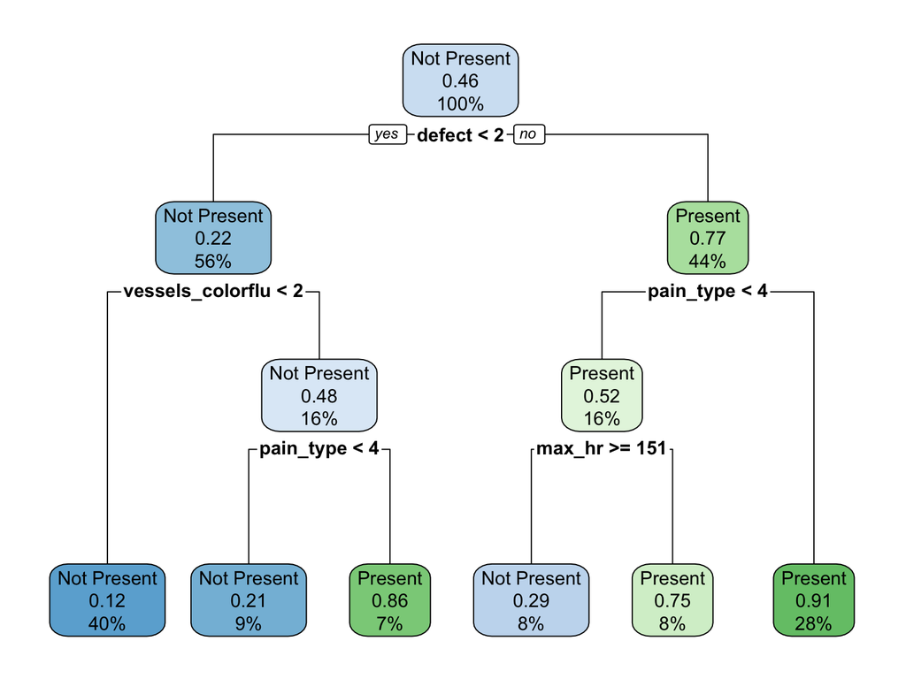

```r
rpart.plot(tree.HD$finalModel)
```

```r
pred.HD<-predict(tree.HD, testing)
pred.HD.prob<-predict(tree.HD, testing, type="prob")

eval.results<-confusionMatrix(pred.HD, testing$outcome, positive = "Present")
print(eval.results)
```

```
## Confusion Matrix and Statistics
##
##              Reference
## Prediction    Not Present Present
##   Not Present          40       8
##   Present               8      33
##
##                Accuracy : 0.8202
##                  95% CI : (0.7245, 0.8936)
##     No Information Rate : 0.5393
##     P-Value [Acc > NIR] : 2.567e-08
##
##                   Kappa : 0.6382
##
##  Mcnemar's Test P-Value : 1
##
##             Sensitivity : 0.8049
##             Specificity : 0.8333
##          Pos Pred Value : 0.8049
##          Neg Pred Value : 0.8333
##              Prevalence : 0.4607
##          Detection Rate : 0.3708
##    Detection Prevalence : 0.4607
##       Balanced Accuracy : 0.8191
##
##        'Positive' Class : Present
##
```

```r
analysis <- roc(response=testing$outcome, predictor=pred.HD.prob[,2])
```

[figure not shown]

```r
plot(1-analysis$specificities,analysis$sensitivities,type="l",
ylab="Sensitiviy",xlab="1-Specificity",col="black",lwd=2,
main = "ROC Curve for Greater Firearm Fatalities")
abline(a=0,b=1)
```

#### Question 3

The next thing I will do is run a random forest to classify heart disease. I will set up a pipeline to try different values of mtry and different numbers of trees to obtain your optimal model. After this I will then run the evaluation metrics and outputting the important variables metrics.

```r
rf.HD<-randomForest(outcome ~., data=training, mtry=sqrt(ncol(training)-1), importance=TRUE, ntree=100)

rf.HD
```

```
##
## Call:
##  randomForest(formula = outcome ~ ., data = training, mtry = sqrt(ncol(training) -      1), importance = TRUE, ntree = 100)
##                Type of random forest: classification
##                      Number of trees: 100
## No. of variables tried at each split: 4
##
##         OOB estimate of  error rate: 22.12%
## Confusion matrix:
##             Not Present Present class.error
## Not Present          93      19   0.1696429
## Present              27      69   0.2812500
```

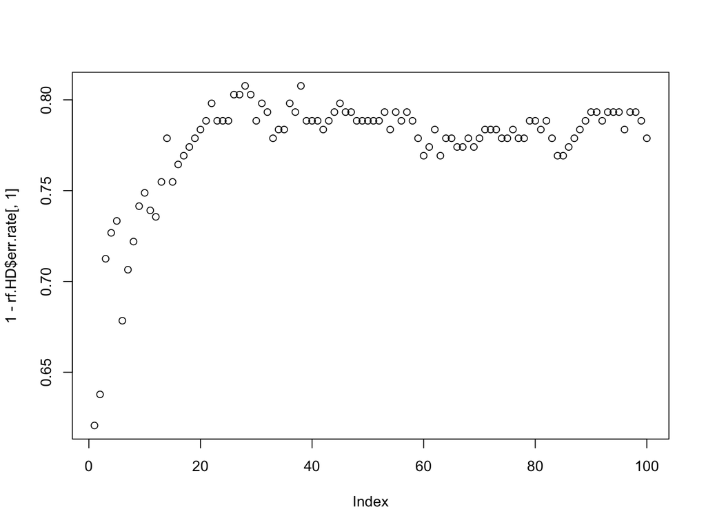

```r
#Create plot of Accuracy by tree index
plot(1-rf.HD$err.rate[,1])
```

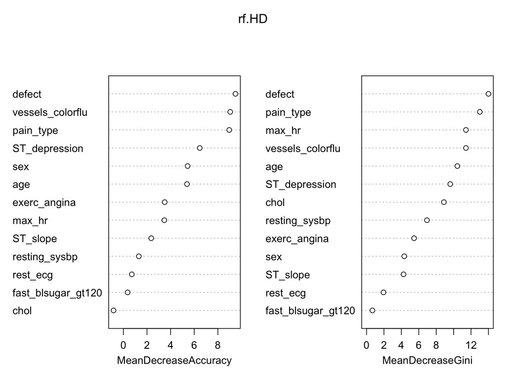

```r
#Examine variable importance plots
varImpPlot(rf.HD)
```

```r
rf.HD.2<-randomForest(outcome ~., data=training, mtry=sqrt(ncol(training)-1), importance=TRUE, ntree=200)

rf.HD.2
```

```
##
## Call:
##  randomForest(formula = outcome ~ ., data = training, mtry = sqrt(ncol(training) -      1), importance = TRUE, ntree = 200)
##                Type of random forest: classification
##                      Number of trees: 200
## No. of variables tried at each split: 4
##
##         OOB estimate of  error rate: 22.12%
## Confusion matrix:
##             Not Present Present class.error
## Not Present          91      21   0.1875000
## Present              25      71   0.2604167
```

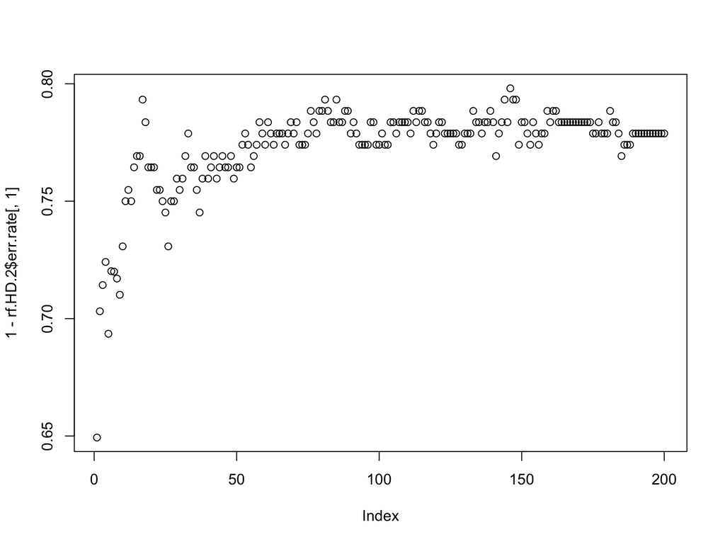

```r
#Create plot of Accuracy by tree index
plot(1-rf.HD.2$err.rate[,1])
```

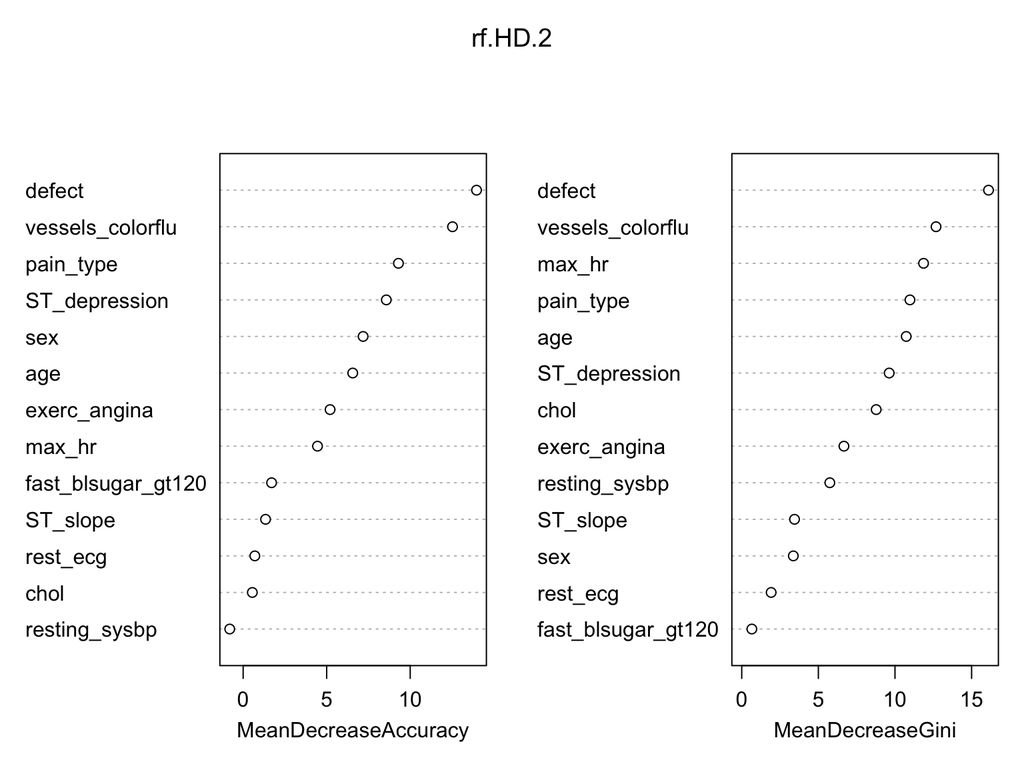

```r
#Examine variable importance plots
varImpPlot(rf.HD.2)
```

```r
rf.HD.3<-randomForest(outcome ~., data=training, mtry=sqrt(ncol(training)-1), importance=TRUE, ntree=300)

rf.HD.3
```

```
##
## Call:
##  randomForest(formula = outcome ~ ., data = training, mtry = sqrt(ncol(training) -      1), importance = TRUE, ntree = 300)
##                Type of random forest: classification
##                      Number of trees: 300
## No. of variables tried at each split: 4
##
##         OOB estimate of  error rate: 21.63%
## Confusion matrix:
##             Not Present Present class.error
## Not Present          92      20   0.1785714
## Present              25      71   0.2604167
```

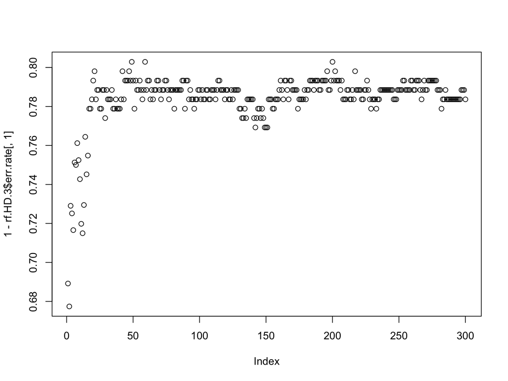

```r
#Create plot of Accuracy by tree index
plot(1-rf.HD.3$err.rate[,1])
```

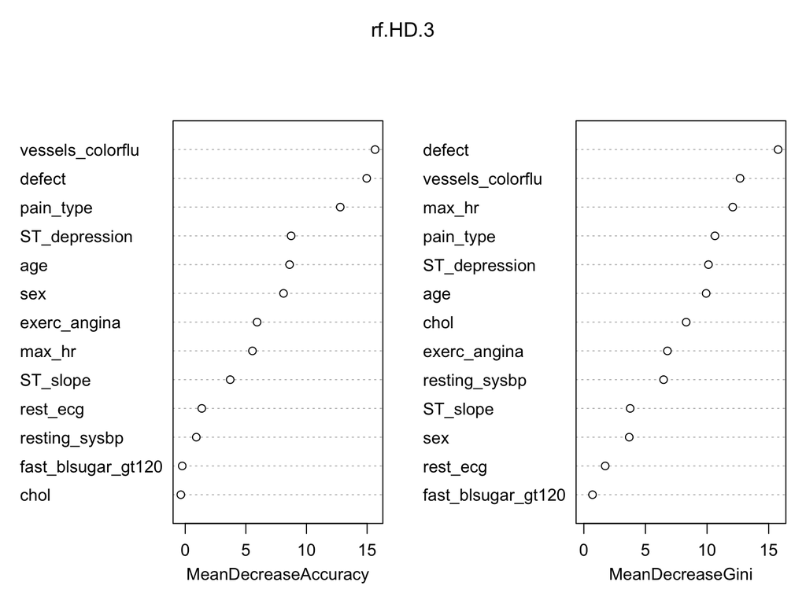

```r
#Examine variable importance plots
varImpPlot(rf.HD.3)
```

```r
#Vary value of mtry-First decrease from 8 to 5

rf.HD.4<-randomForest(outcome ~., data=training, mtry=5, importance=TRUE, ntree=300)

rf.HD.4
```

```
##
## Call:
##  randomForest(formula = outcome ~ ., data = training, mtry = 5,      importance = TRUE, ntree = 300)
##                Type of random forest: classification
##                      Number of trees: 300
## No. of variables tried at each split: 5
##
##         OOB estimate of  error rate: 23.08%
## Confusion matrix:
##             Not Present Present class.error
## Not Present          90      22   0.1964286
## Present              26      70   0.2708333
```

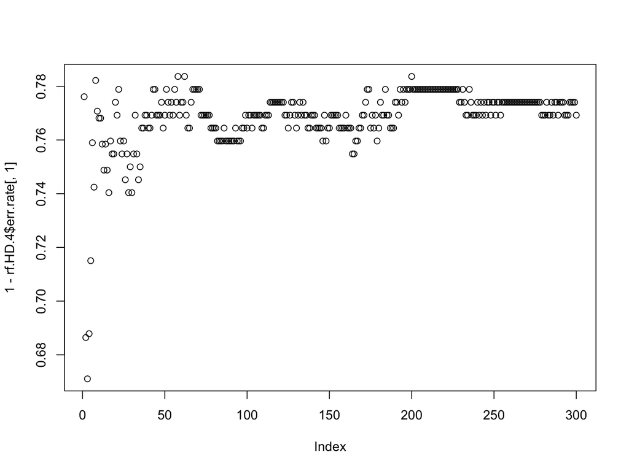

```r
#Create plot of Accuracy by tree index
plot(1-rf.HD.4$err.rate[,1])
```

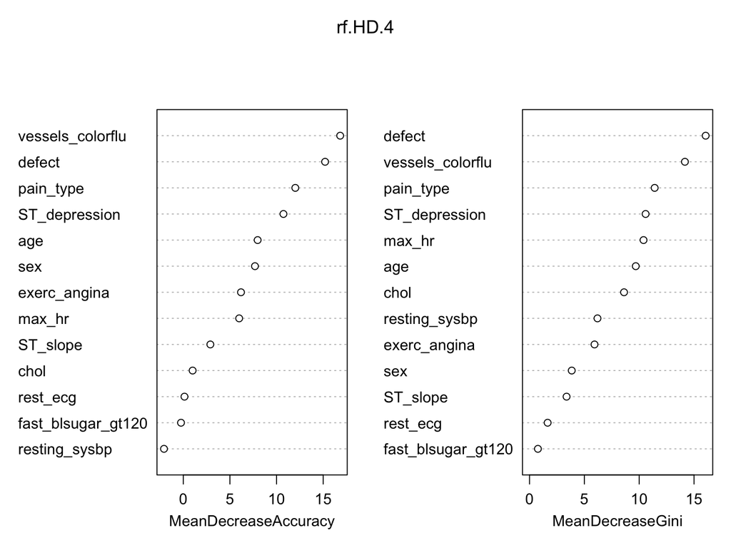

```r
#Examine variable importance plots
varImpPlot(rf.HD.4)
```

```r
#Vary value of mtry-Try increase to 20

rf.HD.5<-randomForest(outcome ~., data=training, mtry=20, importance=TRUE, ntree=300)

rf.HD.5
```

```
##
## Call:
##  randomForest(formula = outcome ~ ., data = training, mtry = 20,      importance = TRUE, ntree = 300)
##                Type of random forest: classification
##                      Number of trees: 300
## No. of variables tried at each split: 13
##
##         OOB estimate of  error rate: 22.12%
## Confusion matrix:
##             Not Present Present class.error
## Not Present          90      22   0.1964286
## Present              24      72   0.2500000
```

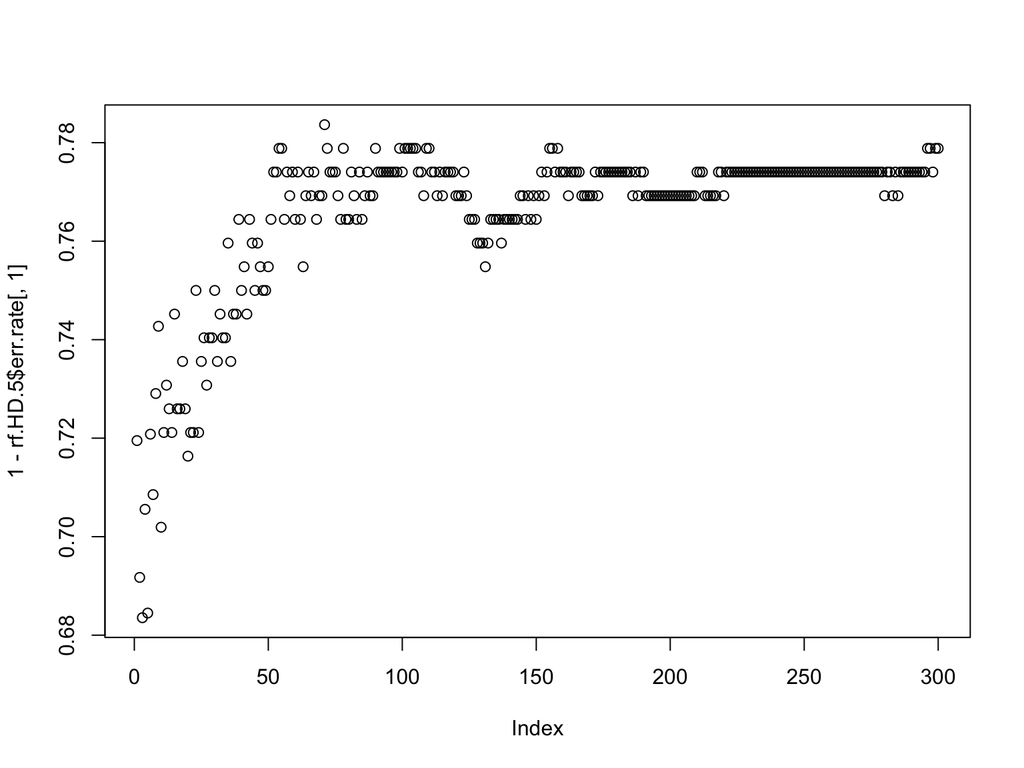

```r
#Create plot of Accuracy by tree index
plot(1-rf.HD.5$err.rate[,1])
```

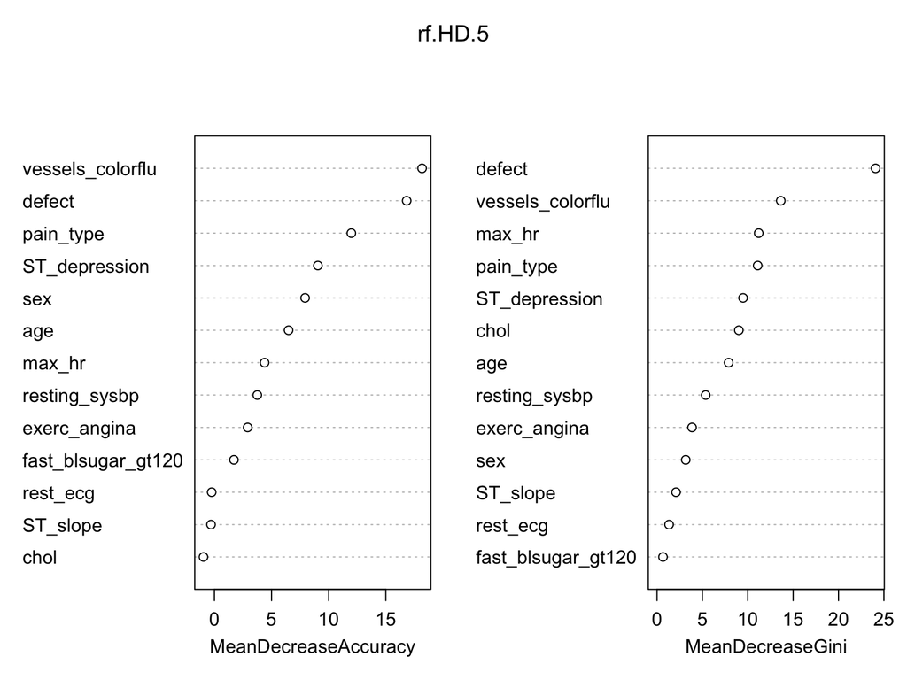

```r
#Examine variable importance plots
varImpPlot(rf.HD.5)
```

```r
#Vary value of mtry-Try increase to half of the features, 33

rf.HD.6<-randomForest(outcome ~., data=training, mtry=0.5*(ncol(training)-1), importance=TRUE, ntree=300)

rf.HD.6
```

```
##
## Call:
##  randomForest(formula = outcome ~ ., data = training, mtry = 0.5 *      (ncol(training) - 1), importance = TRUE, ntree = 300)
##                Type of random forest: classification
##                      Number of trees: 300
## No. of variables tried at each split: 6
##
##         OOB estimate of  error rate: 20.67%
## Confusion matrix:
##             Not Present Present class.error
## Not Present          93      19   0.1696429
## Present              24      72   0.2500000
```

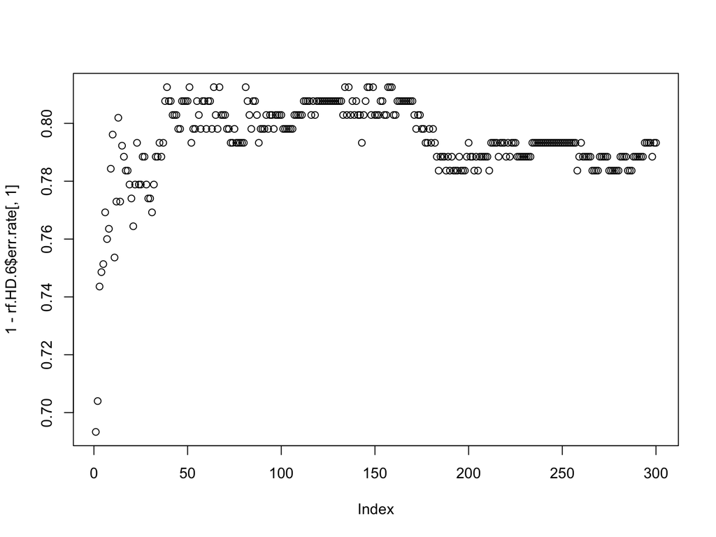

```r
#Create plot of Accuracy by tree index
plot(1-rf.HD.6$err.rate[,1])
```

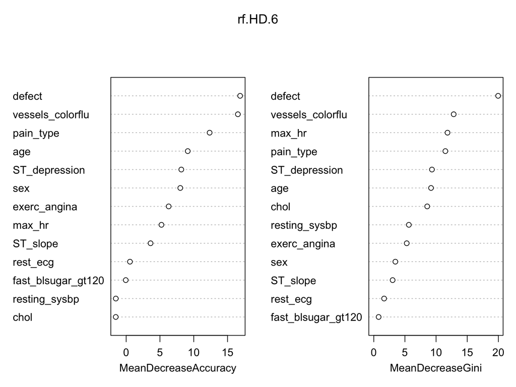

```r
#Examine variable importance plots
varImpPlot(rf.HD.6)
```

#### Question 4

Are there differences in variable importance that you see between a single tree and an ensemble metric?

Yes, there are some difference in variable importance that I see between a single tree and an ensemble metric. The variable importance for the single classification tree is pain_type while in the ensemble the most importnat variable in this model is defect.

Are there differences observed across the different variable importance metrics output from the ensemble?

Yes, there are some differences across the different variable importance metrics output from the ensemble. Some metrics say that defect is the most imoportant variable while others say that vessels_colorflu is the most important model.

How do you interpret those differences?

Those differences are interpretted as which variables are used in the model and which varible explains the decrease in accuracies that is observed.

#### Question 5

The next thing that I will do is use a boosting algorithm and tune to obtain your optimal model. Compare to the results from the single classification tree and the random forest.

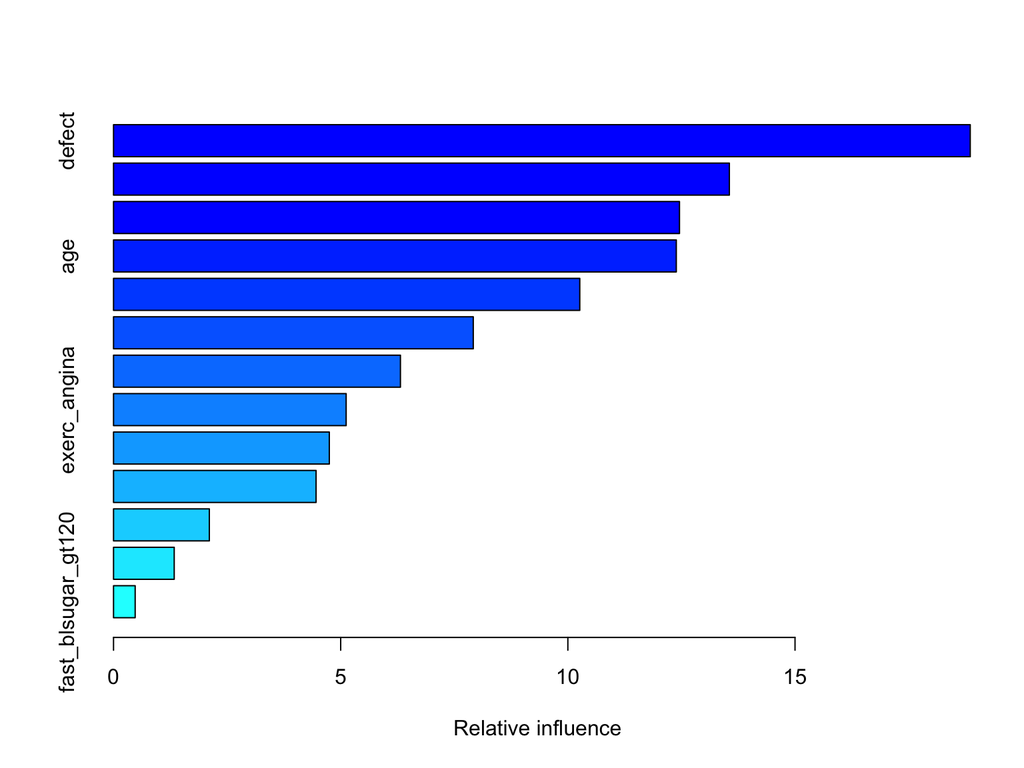

```
##                                   var    rel.inf
## defect                         defect 18.8566188
## vessels_colorflu     vessels_colorflu 13.5547144
## pain_type                   pain_type 12.4568288
## age                               age 12.3868610
## ST_depression           ST_depression 10.2624112
## max_hr                         max_hr  7.9180951
## chol                             chol  6.3148933
## exerc_angina             exerc_angina  5.1203699
## resting_sysbp           resting_sysbp  4.7495449
## sex                               sex  4.4584132
## ST_slope                     ST_slope  2.1089542
## rest_ecg                     rest_ecg  1.3358641
## fast_blsugar_gt120 fast_blsugar_gt120  0.4764309
```

```r
train.data=
  training %>%
    mutate(outcome.num = recode(outcome, "Present"= 1, "Not Present" = 0))

train.data$outcome<-NULL

#leaving cvar importance as the default
gbm.outcome<-gbm(outcome.num ~., data=train.data, distribution='bernoulli', n.trees=2000, shrinkage=0.01)
summary(gbm.outcome)
```

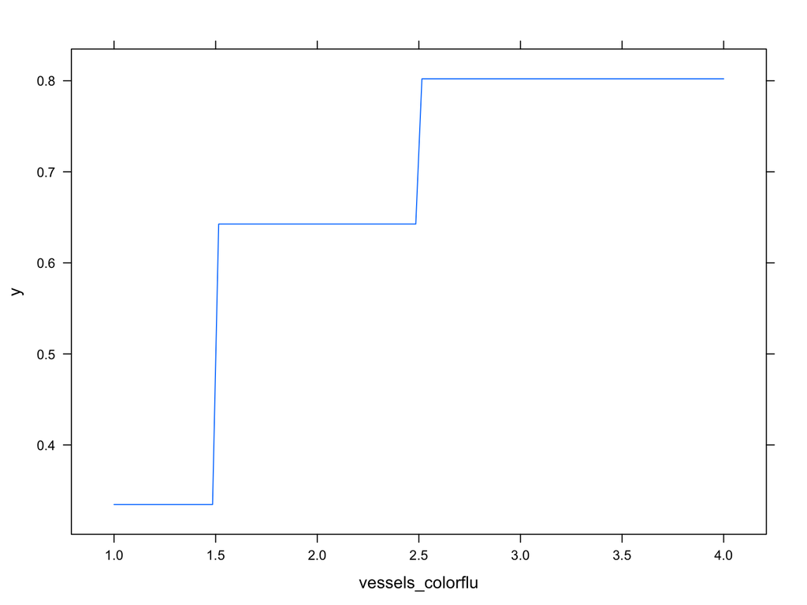

```r
#plot of the marginal effect of the selected variable
plot.gbm(gbm.outcome, 'vessels_colorflu', type="response")
```

```
## OOB generally underestimates the optimal number of iterations although predictive performance is reasonably competitive. Using cv_folds>1 when calling gbm usually results in improved predictive performance.
```

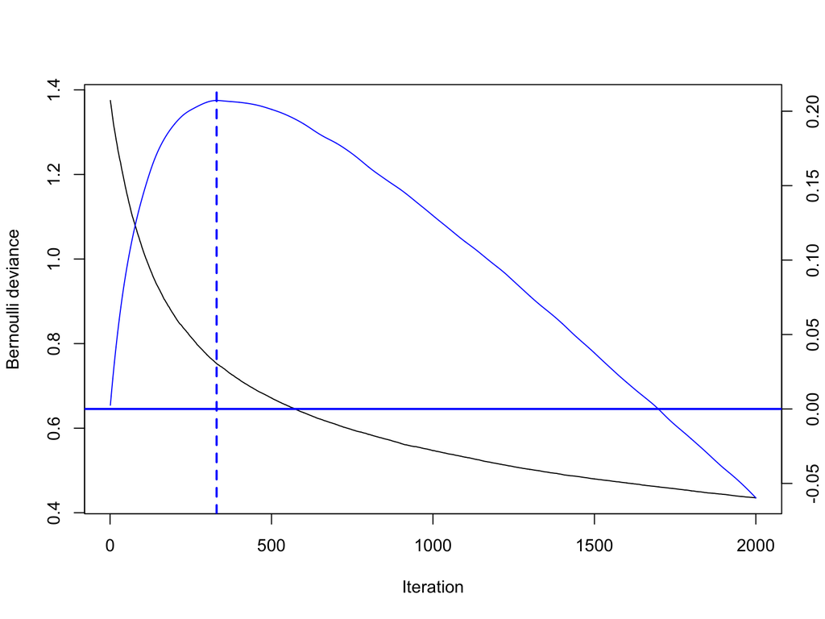

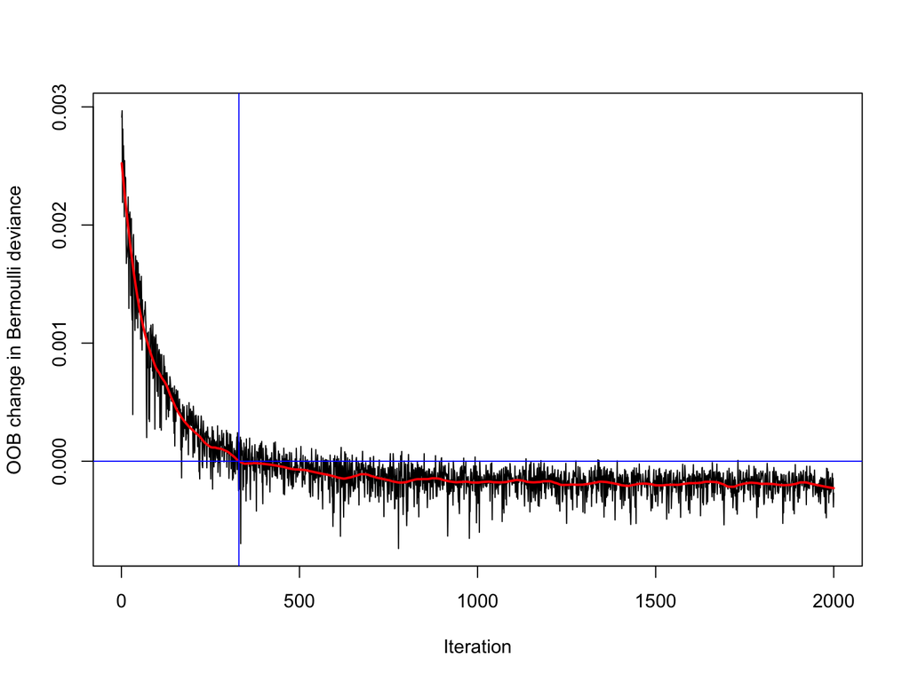

```
## [1] 330
## attr(,"smoother")
## Call:
## loess(formula = object$oobag.improve ~ x, enp.target = min(max(4,
##     length(x)/10), 50))
##
## Number of Observations: 2000
## Equivalent Number of Parameters: 39.99
## Residual Standard Error: 0.0001289
```

```r
#Plot loss function as a result of n trees added to the ensemble
gbm.perf(gbm.outcome, plot.it=TRUE, oobag.curve=TRUE, overlay=TRUE, method='OOB')
```

```r
pred.gbm.outcome<-predict(gbm.outcome, train.data, n.trees=2000, type="response")

pred.gbm.outcome.class<-round(pred.gbm.outcome)

misClasificError <- mean(pred.gbm.outcome.class != train.data$outcome.num)
print(paste('Accuracy Model',1-misClasificError))
```

```
## [1] "Accuracy Model 0.923076923076923"
```

#### Question 6

Which model performs the best? Provide justification for your answer.

The model that performed best in this analysis would be the single classification with an accuracy of 82%. The accurancy in the boosting random forest is 92% which suggest some overfitting happening in the model, therefore the single classification tree would be better because it would be more generalizable to other populations.

#### Question 7

How do these results compare to the SVC analysis we did back in Class 6?

Code from class 6- Suppoert Vector Machine

```r
set.seed(100)
svm.heart<-svm(outcome ~ ., data=training, kernel="linear", cost=1, scale=TRUE)
print(svm.heart)
```

```
##
## Call:
## svm(formula = outcome ~ ., data = training, kernel = "linear",
##     cost = 1, scale = TRUE)
##
##
## Parameters:
##    SVM-Type:  C-classification
##  SVM-Kernel:  linear
##        cost:  1
##
## Number of Support Vectors:  74
```

```r
### Cost- hyper parameter
svm.pred<-predict(svm.heart, newdata=training[,1:13])
table(svm.pred, training$outcome)
```

```
##
## svm.pred      Not Present Present
##   Not Present         101      18
##   Present              11      78
```

```r
misClasificError <- mean(svm.pred != training$outcome, na.rm=T)
print(paste('Accuracy Model 1',1-misClasificError))
```

```
## [1] "Accuracy Model 1 0.860576923076923"
```

```r
features<-training[,1:13]
outcome<-training$outcome

svm_tune <- tune(svm, train.x=features, train.y=outcome,  kernel="linear", range=list(cost=10^(-1:2)))

summary(svm_tune)
```

```
##
## Parameter tuning of 'svm':
##
## - sampling method: 10-fold cross validation
##
## - best parameters:
##  cost
##   0.1
##
## - best performance: 0.1490476
##
## - Detailed performance results:
##    cost     error dispersion
## 1   0.1 0.1490476  0.1041843
## 2   1.0 0.1492857  0.1044250
## 3  10.0 0.1590476  0.1154799
## 4 100.0 0.1590476  0.1154799
```

```r
svm.heart.new<-svm(outcome ~ ., data=training, kernel="linear", cost=0.1,  scale=TRUE)

print(svm.heart.new)
```

```
##
## Call:
## svm(formula = outcome ~ ., data = training, kernel = "linear",
##     cost = 0.1, scale = TRUE)
##
##
## Parameters:
##    SVM-Type:  C-classification
##  SVM-Kernel:  linear
##        cost:  0.1
##
## Number of Support Vectors:  86
```

```r
svm.pred.new<-predict(svm.heart.new, newdata=training[,1:13])
table(svm.pred.new, training$outcome)
```

```
##
## svm.pred.new  Not Present Present
##   Not Present         102      18
##   Present              10      78
```

```r
misClasificError.new <- mean(svm.pred.new != training$outcome, na.rm=T)
print(paste('Accuracy Model 1',1-misClasificError.new))
```

```
## [1] "Accuracy Model 1 0.865384615384615"
```